# SMSC Migratory Birds: Home Range Lab

N Simon Sanghera

13/12/2019

#———— Taught by Luke Powell

**Overview**  
Learn to calculate animal home ranges using the adehabitatHR package in R.  
Types will be Minimum Convex Polygon and Kernel Density Estimator  
Also, how to calculate home ranges in 3D.

https://ecosystems.psu.edu/research/labs/walter-lab/manual https://scbi-migbirds.github.io/homeRange.html

#### Set-up

Install packages and load libraries

```r
libraries <-
  c(
    "tidyverse",
    "ggplot2",
    "adehabitatHR",
    "maptools"
  )

purrr::map(
  libraries,
  function(x) {
    library(x, character.only = TRUE)
  }
)
```

```
## deldir 0.1-23
```

```
## Checking rgeos availability: TRUE
```

[output not shown]

Import the birds location data. The data are in UTM format, units are metres.

```r
locs <- read.csv("HomeRange/HR_data/RSHomeRangeData.csv",
                  header = T,
                  na.strings = c("NA", "NULL", "", "."))
# na.strings replaces missing values with "NA"

#locs <- import
```

Have a quick look at the data for each of the three birds

```r
table(locs$bird)
```

```
##
##  RSFA_BK,O RSMBK,BK_A   YWFA,Y_G
##         99         89         23
```

Import the telemetry data

```r
telem <- read.csv("HomeRange/HR_data/RawBrazilTelemData26aug2014.csv",
                  header = T,
                  na.strings = c("NA", "NULL", "", "."))
```

### Prepare for Triangulations

*Raw vs Adjusted Azimuth* (compass bearing)  
It is possible to use an uncorrected compass and make corrections later, or use a compass that aloows adjustments to declination to be made on the compass itself.  
Or we can calculate declination (the angular distance of a point north or south of the celestial equator).  
At most places on the Earth’s surface, the compass does’t point exactly towards geographic north. The deviation ofthe compass from **TRUE NORTH** is an angle called **DECLINATION** (or magnetic declination).

#### Conditions that affect radioteletry:

- topography
- wet vegetation
- distance to animal
- size of transmitter
- animal behaivour

#### How to triangulate data

Two pieces of software are readily available on PCs:  
- LOCATE III: free program, but buggy  
- LOAS: expensive, not buggy

#### Home-Range: how many points until home range stabilizes?

- 2D: usually 30 - 50 *independent* points is usually enough (Seamen *et al.* 1999, JWM)
- 3D: around 80 independent points (Cooper *et al.*, 2014, The Auk)
- Discuss biological (Lair, 1987) vs statistical independence
- It is possible to use bootstrapping to perform an asymptote analysis
- One can check the animals one-by-one (although this is time consuming)

#### Note:

Home Range Area Curve = plots the number of independent locations on the x-axis against the estimated home-range size on the y-axis. From the plot, the number of required locations is denoted when increasinf the number of locations does NOT result in an increasing home-range size (i.e. asymptotes of the graph) (Haines *et al.*, 2009)

### Prepare data for adehabitatHR

Extracting just the x and y data

```r
xyt <- subset(locs, select = c(X, Y))
```

Extracting just the bird IDs

```r
bird_id <- subset(locs, select = bird)
```

Creating a SpatialPointsDataFrame for the package adehabitatHR  
**SpatialPointsDataFrame** =

```r
locs_1              <- bird_id
coordinates(locs_1) <- xyt

class(locs_1)
```

```
## [1] "SpatialPointsDataFrame"
## attr(,"package")
## [1] "sp"
```

Plot the point data

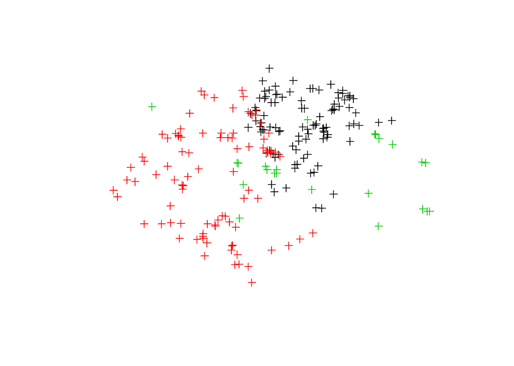

```r
plot(locs_1,
     col = as.data.frame(locs_1)[, 1])
```

### Minimum Convex Polygons

Running the 95% Minimum Convex Polygon analysis  
This method calculates the smallest polygon enclosing 95% (removing 5% of the most extreme points) of the relocations of the animal. It is considered to be the home range of the animal.  
*home range* is defined as the area traversed by the animal during its **normal** activities of foraging, mating, caring for young. Due to this reason, it is common to remove a small percentage of the relocations furthest from the centroid of the cloud of relocations before estimations.  
MCP can be used to describe the extent of distribution of locations of an animal but **NOT** as an estimation of home rnage size.

```r
locs_1_cp <- mcp(locs_1[, 1],
                 percent = 95)
```

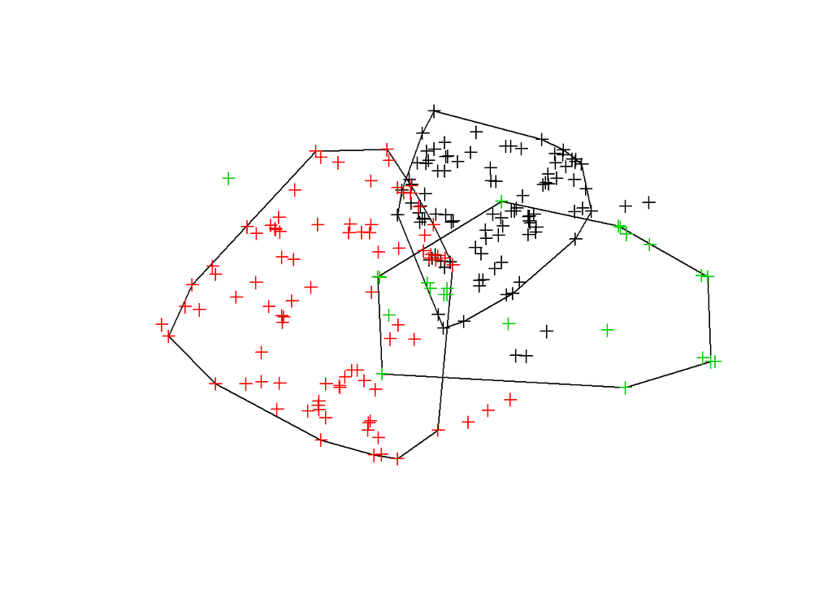

```r
plot(locs_1_cp)

plot(locs_1,
     col = as.data.frame(locs_1)[, 1],
     add = T)
```

```r
# adding colour for each species
```

Obtain the area of the polygon

```r
locs_1_cp
```

```
## Object of class "SpatialPolygonsDataFrame" (package sp):
##
## Number of SpatialPolygons:  3
##
## Variables measured:
##                    id      area
## RSFA_BK,O   RSFA_BK,O 0.1021694
## RSMBK,BK_A RSMBK,BK_A 0.2216984
## YWFA,Y_G     YWFA,Y_G 0.1786882
```

Write the polygon to a shapefile

```r
writePolyShape(locs_1_cp, "HomeRange/HR_data/RS_mcp")
```

writePolyShape is deprecated; use rgdal::writeOGR or sf::st_write

### Kernel Density Estimation in 2D

#==== Kernel Density Estimation ====# This is a non-parametric method of estimating the probability density function of a random variable. It is a fundamental data smoothing problem where inferences about the population (data points/locations) are made based on a finited data sample.  
It is used to delineate where geo-tracked animals spend their time.  
KDE optimizers are sensitive to temporal autocorrelation.  
#==== ====#

Now we will calculate home range size using the kernel density estimator.  
It uses a *Utilization Distribution* (UD) to calculate home range size based on the distribution of the points.  
Under this model, it is considered that animals use of space can be described by a *bivariate* probability density function.  
This gives the probability density to relocate the animal at any place according to the coordinates (x, y) of this place.  
Home range sizes can be calculated by running the *Kernel Density Estimation* (KDE) using the *Least Square Cross Validation* technique.  
A bivariate kernel function is placed over each relocation, and the values of these functions are averaged together.  
Least-Squares Cross Validation is suggested to be better at identifying distributions with tight clumps.  
(Note: h is the smoothing parameter - this controls the width of the kernel functions placed over each point)

```r
locs_1_kud <- kernelUD(locs_1[, 1],
                       h = "LSCV")
```

Converting the KDE as vectors:

```r
homerange_locs_1 <- getverticeshr(locs_1_kud)
```

```r
class(homerange_locs_1)
```

```
## [1] "SpatialPolygonsDataFrame"
## attr(,"package")
## [1] "sp"
```

Plot the vector

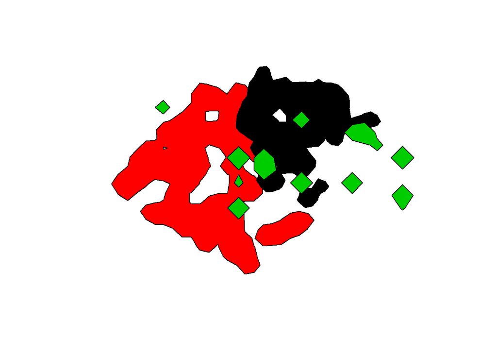

```r
plot(homerange_locs_1,
     col = 1:3)
```

Calculating the area for the different *isopleths* (UDs).  
- areas are in hectares  
- 95% is the standard for “home range size”  
- 50% is often used for the core area

```r
locs_1_kde_area <- kernel.area(locs_1_kud,
                               percent = c(50, 95))
```

```r
locs_1_kde_area
```

```
##     RSFA_BK.O RSMBK.BK_A   YWFA.Y_G
## 50 0.03457259 0.05955412 0.01135100
## 95 0.12737271 0.22303603 0.03405299
```

Plot the different isopleths:  
- for the second animal only

[figure not shown]

```r
# First get volume of the UD
vud_2 <- getvolumeUD(locs_1_kud)
image(vud_2[[2]])
xyzv <- as.image.SpatialGridDataFrame(vud_2[[2]])
contour(xyzv, add = TRUE)
```

GPS data are autocorrelated - so they can pose difficulties in estimating the bandwidth and violate assumptions of independence of locations that are inherent to the KDE.  
Datasets for avian and mammal species can include > 10,000 locations, and only the reference or default bandwidth (**href**) was able to produce KDE in adehabitat.  
Estimation with href is NOT reliable for use on multimodal datasets because it results in over-smoothing of home ranges and the multimodal distribution of locations is typical for most species.

Obtain the KDE home range using href  
- use href instead of LSCV because the isolated home range blobs look odd

```r
kudhref <- kernelUD(locs_1[, 1],
                    h = "href")
```

Convert the 95% KDE as vectors

```r
homerange_locs_1href <- getverticeshr(kudhref,
                                      percent = 95)
```

Plot the vector and points

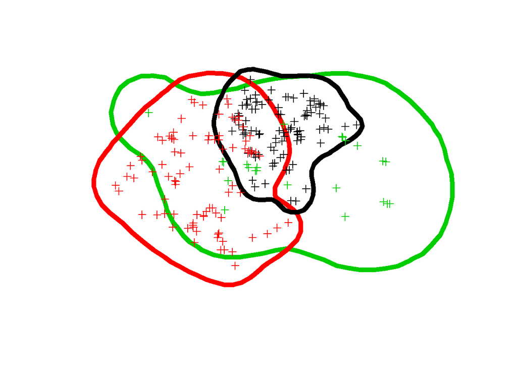

```r
plot(homerange_locs_1href,
     border = 1:3,
     lwd = 6)

plot(locs_1,
     col = as.data.frame(locs_1)[, 1],
     add = T)
```

This does look slightly better than before.  
It is important to relate this to the ecology of the species, which might determine the home range method used.

Export shapefile

```r
writePolyShape(homerange_locs_1href,
               "HomeRange/HR_data/95kde_href")
```

Core Area: Using 50 KDE as vectors

```r
homerange_locs_1href_core <- getverticeshr(kudhref,
                                           percent = 50)
```

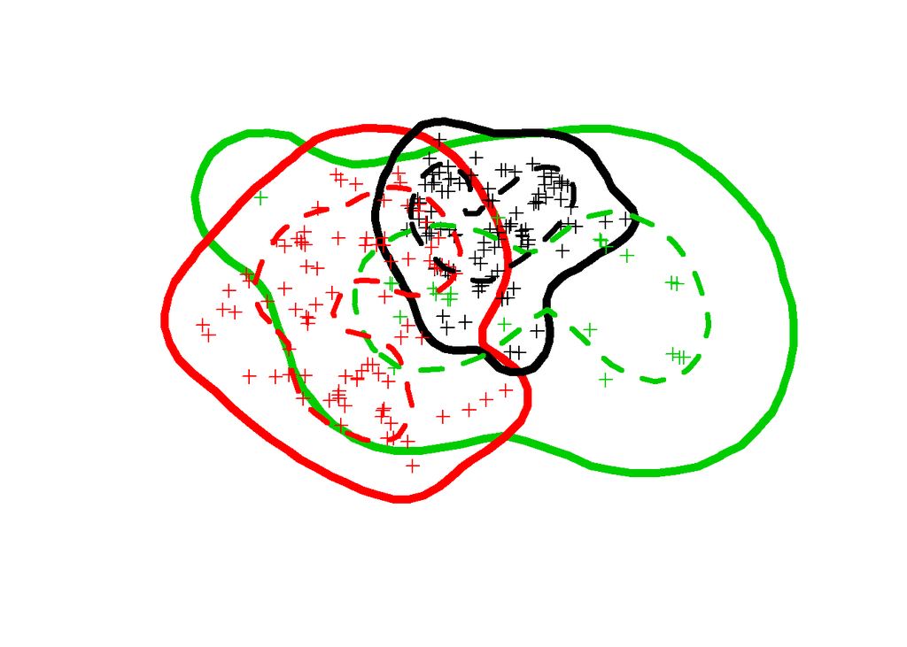

```r
plot(homerange_locs_1href,
     border = 1:3,
     lwd = 6)

plot(locs_1,
     col = as.data.frame(locs_1)[, 1],
     add = T)

plot(homerange_locs_1href_core,
     border = 1:3,
     lwd = 4,
     lty = "dashed",
     add = T)
```

Final plot showing locations within the typically associated 95% home range boundaries and core areas for common scale-backed antbird *Willisornis poecilinotus*, black-headed antbird *Percnostola rufifrons*, and rufous-capped anthrush *Formicarius colma*.

```r
writePolyShape(homerange_locs_1href_core,
               "HomeRange/HR_data/core_50_kde_href")
```

#——

## 3D Kernel Density Estimation

### Data Prep

```
## Copyright M. P. Wand 1997-2009
```

[output not shown]

Remove the column called “rec” from the locations dataset - this will leave us with just the X, Y, Z and bird columns.

```r
locs_3D <- dplyr::select(locs, -(rec))
```

Split the locations object (locs_3D) into 3 different objects:  
- one per animal  
- call objects after names in bird column - remove bird column from each new dataframe

```r
YWFA <- locs_3D %>%
  dplyr::filter(bird == "YWFA,Y_G") %>%
  dplyr::select(X, Y, Z)
```

```r
RSFA <- locs_3D %>%
  dplyr::filter(bird == "RSFA_BK,O") %>%
  dplyr::select(X, Y, Z)
```

```r
RSMBK <- locs_3D %>%
  dplyr::filter(bird == "RSMBK,BK_A") %>%
  dplyr::select(X, Y, Z)
```

### 3D Data Analyses

A kernel distribution (3-dimensional hill or kernel) is place on each telemetry location. The height of the hill is determined by the **bandwidth** of the distribution.  
Many distributions and methods are available:  
- fixed  
- fixed vs adaptive  
- univariate  
- bivariate

This calls the plug-in bandwidth estimator. This is generally accepted as safest. If the resulting territories are lots of separated pieces, it is possible to multiply the Hpi by factors larger than 1.

```r
H_YWFA <- Hpi(YWFA)
H_RSFA <- Hpi(RSFA)
H_RSMBK <- Hpi(RSMBK)
```

Join 2 of the datasets and then determine maximum and minimum for each dimension.  
It is important that overlapping territories are evaluated in the same physical space.  
It is a good idea to add buffer points so that no part of the territories are cut off.

```r
YWFA_RSFA <- rbind(YWFA, RSFA)

minX <- min(YWFA_RSFA$X) - 25
minY <- min(YWFA_RSFA$Y) - 25
minZ <- 0
```

```r
maxX <- max(YWFA_RSFA$X) + 25
maxY <- max(YWFA_RSFA$Y) + 25
maxZ <- max(YWFA_RSFA$Z) + 5
```

Kernel density analyses:  
- gridsize = number of 3D pixels / voxels that the space is divided up into

```r
fhat_YWFA <- kde(x = YWFA,
                 H = H_YWFA,
                 binned = FALSE,
                 xmin = c(minX, minY, minZ),
                 gridsize = 151,
                 xmax = c(maxX, maxY, maxZ))
```

```r
fhat_RSFA <- kde(x = RSFA,
                 H = H_RSFA,
                 binned = FALSE,
                 xmin = c(minX, minY, minZ),
                 gridsize = 151,
                 xmax = c(maxX, maxY, maxY))
```

```r
fhat_RSMBK <- kde(x = RSMBK,
                  H = H_RSMBK,
                  binned = FALSE,
                  xmin = c(minX, minY, minZ),
                  gridsize = 151,
                  xmax = c(maxX, maxY, maxZ))
```

Calculate the isopleth at 95%  
- ct just produces a number  
- this all voxels with a density greater than ct_YWFA would be in that isopleth

```r
ct_YWFA <- contourLevels(fhat_YWFA,
                         cont = 95,
                         approx = FALSE)
```

```r
ct_RSFA <- contourLevels(fhat_RSFA,
                         cont = 95,
                         approx = FALSE)
```

```r
ct_RSMBK <- contourLevels(fhat_RSMBK,
                          cont = 95,
                          approx = FALSE)
```

Calculate the volume of each territory at 95th isopleth.  
If UTMs used, then the units should be m<sup>3</sup>.

```r
vol_95_ywfa <- contourSizes(fhat_YWFA,
                            cont = 95)
```

```r
vol_95_rsfa <- contourSizes(fhat_RSFA,
                            cont = 95)
```

```r
vol_95_rsmbk <- contourSizes(fhat_RSMBK,
                             cont = 95)
```

Plot the home ranges in 3D:

```r
plot(fhat_YWFA,
     cont = c(95),
     colors = ("green"),
     drawpoints = TRUE,
     xlab = "",
     ylab = "",
     zlab = "",
     xlim = c(minX, maxX),
     ylim = c(minY, maxY),
     zlim = c(minZ, maxZ),
     size = 2,
     ptcol = "green")
```

[output not shown]